# RNA-Seq Data Analysis: Acute activation of ER-RAC1 P29S in melanocytes GSE118349

philip.east@crick.ac.uk

Compiled: 12 June, 2019 @ 17:22:12

```r
library( DESeq2 )
library( ggplot2 )
library( limma )
library( scales )

options( max.print=300, width=100 )
```

# Introduction

This R markdown document details the analysis of RNA-Seq data submitted to [GEO GES118349](https://www.ncbi.nlm.nih.gov/geo/query/acc.cgi?acc=GSE118349) and published in Cancer Cell 36, 1-16 July 8, 2019.

An ER-RAC1 P29S fusion protein was stably expressed in the spontaneously immortalized mouse melanocyte cell line melan-a. The fusion protein was activated by treatment with 500 nM 4OH-tamoxifen. RNA was isolated and sequenced at 0 h, 4 h and 40 h post-treatment. The gene expression profiles at 4 h and 40 h were compared to the 0 h time-point. To control for effects induced by 4OH-tamoxifen independent from ER-RAC1 P29S, we performed the same experiment in melan-a cells transduced with an empty vector.

# Load ExpressionSets

Here we load the data as ExpressionSet objects containing raw counts and TPMs.

```r
load( file = "eset_counts_GSE118349.rda" )
eset_counts
```

```
## ExpressionSet (storageMode: lockedEnvironment)
## assayData: 32958 features, 18 samples
##   element names: exprs
## protocolData: none
## phenoData
##   sampleNames: 1310ap00_1_1 1310ap04_1_1 ... 1510he40_1_1 (18 total)
##   varLabels: sample.id run ... replicates (16 total)
##   varMetadata: labelDescription
## featureData
##   featureNames: uc007aet.1 uc007afo.2 ... uc007wfm.1 (32958 total)
##   fvarLabels: mm10.knownGene.chrom mm10.knownGene.strand ... mm10.kgXref.tRnaName (16
##     total)
##   fvarMetadata: labelDescription
## experimentData: use 'experimentData(object)'
## Annotation:
```

```r
load( file = "eset_TPM_GSE118349.rda" )
eset_TPM
```

```
## ExpressionSet (storageMode: lockedEnvironment)
## assayData: 32958 features, 18 samples
##   element names: exprs
## protocolData: none
## phenoData
##   sampleNames: 1310ap00_1_1 1310ap04_1_1 ... 1510he40_1_1 (18 total)
##   varLabels: sample.id run ... replicates (16 total)
##   varMetadata: labelDescription
## featureData
##   featureNames: uc007aet.1 uc007afo.2 ... uc007wfm.1 (32958 total)
##   fvarLabels: mm10.knownGene.chrom mm10.knownGene.strand ... mm10.kgXref.tRnaName (16
##     total)
##   fvarMetadata: labelDescription
## experimentData: use 'experimentData(object)'
## Annotation:
```

# Experimental Design

```r
kable( pData( eset_counts ) )
```

|  | sample.id | run | lane | ngs | sample.label | rundir | date | molecule | protocol | read.length | runtype | organism | total.reads | cell_line | treatment.hours | replicates |
| --- | --- | --- | --- | --- | --- | --- | --- | --- | --- | --- | --- | --- | --- | --- | --- | --- |
| 1310ap00_1_1 | 1310ap00_1_1 | 597 | 6 | NGS-9817 | 1310ap00 | 151222_HWI-D00446_0597_C8707ANXX | 09/11/2015 | RNA | RNA-Seq | 100 | Paired End Illumina Multiplexed | mus_musculus | 53952876 | inducible | 0 | 13 |
| 1310ap04_1_1 | 1310ap04_1_1 | 597 | 6 | NGS-9818 | 1310ap04 | 151222_HWI-D00446_0597_C8707ANXX | 09/11/2015 | RNA | RNA-Seq | 100 | Paired End Illumina Multiplexed | mus_musculus | 60032628 | inducible | 4 | 13 |
| 1310ap40_1_1 | 1310ap40_1_1 | 597 | 6 | NGS-9819 | 1310ap40 | 151222_HWI-D00446_0597_C8707ANXX | 09/11/2015 | RNA | RNA-Seq | 100 | Paired End Illumina Multiplexed | mus_musculus | 37387421 | inducible | 40 | 13 |
| 1310he00_1_1 | 1310he00_1_1 | 597 | 6 | NGS-9814 | 1310he00 | 151222_HWI-D00446_0597_C8707ANXX | 09/11/2015 | RNA | RNA-Seq | 100 | Paired End Illumina Multiplexed | mus_musculus | 75395951 | parental | 0 | 13 |
| 1310he04_1_1 | 1310he04_1_1 | 597 | 6 | NGS-9815 | 1310he04 | 151222_HWI-D00446_0597_C8707ANXX | 09/11/2015 | RNA | RNA-Seq | 100 | Paired End Illumina Multiplexed | mus_musculus | 82121378 | parental | 4 | 13 |
| 1310he40_1_1 | 1310he40_1_1 | 597 | 6 | NGS-9816 | 1310he40 | 151222_HWI-D00446_0597_C8707ANXX | 09/11/2015 | RNA | RNA-Seq | 100 | Paired End Illumina Multiplexed | mus_musculus | 74529433 | parental | 40 | 13 |
| 1410ap00_1_1 | 1410ap00_1_1 | 597 | 7 | NGS-9823 | 1410ap00 | 151222_HWI-D00446_0597_C8707ANXX | 09/11/2015 | RNA | RNA-Seq | 100 | Paired End Illumina Multiplexed | mus_musculus | 68342385 | inducible | 0 | 14 |
| 1410ap04_1_1 | 1410ap04_1_1 | 597 | 7 | NGS-9824 | 1410ap04 | 151222_HWI-D00446_0597_C8707ANXX | 09/11/2015 | RNA | RNA-Seq | 100 | Paired End Illumina Multiplexed | mus_musculus | 67499607 | inducible | 4 | 14 |
| 1410ap40_1_1 | 1410ap40_1_1 | 597 | 7 | NGS-9825 | 1410ap40 | 151222_HWI-D00446_0597_C8707ANXX | 09/11/2015 | RNA | RNA-Seq | 100 | Paired End Illumina Multiplexed | mus_musculus | 72689862 | inducible | 40 | 14 |
| 1410he00_1_1 | 1410he00_1_1 | 597 | 7 | NGS-9820 | 1410he00 | 151222_HWI-D00446_0597_C8707ANXX | 09/11/2015 | RNA | RNA-Seq | 100 | Paired End Illumina Multiplexed | mus_musculus | 46799886 | parental | 0 | 14 |
| 1410he04_1_1 | 1410he04_1_1 | 597 | 7 | NGS-9821 | 1410he04 | 151222_HWI-D00446_0597_C8707ANXX | 09/11/2015 | RNA | RNA-Seq | 100 | Paired End Illumina Multiplexed | mus_musculus | 50730479 | parental | 4 | 14 |
| 1410he40_1_1 | 1410he40_1_1 | 597 | 7 | NGS-9822 | 1410he40 | 151222_HWI-D00446_0597_C8707ANXX | 09/11/2015 | RNA | RNA-Seq | 100 | Paired End Illumina Multiplexed | mus_musculus | 64800382 | parental | 40 | 14 |
| 1510ap00_1_1 | 1510ap00_1_1 | 597 | 8 | NGS-9829 | 1510ap00 | 151222_HWI-D00446_0597_C8707ANXX | 09/11/2015 | RNA | RNA-Seq | 100 | Paired End Illumina Multiplexed | mus_musculus | 118221997 | inducible | 0 | 15 |
| 1510ap04_1_1 | 1510ap04_1_1 | 597 | 8 | NGS-9830 | 1510ap04 | 151222_HWI-D00446_0597_C8707ANXX | 09/11/2015 | RNA | RNA-Seq | 100 | Paired End Illumina Multiplexed | mus_musculus | 8510994 | inducible | 4 | 15 |
| 1510ap40_1_1 | 1510ap40_1_1 | 597 | 8 | NGS-9831 | 1510ap40 | 151222_HWI-D00446_0597_C8707ANXX | 09/11/2015 | RNA | RNA-Seq | 100 | Paired End Illumina Multiplexed | mus_musculus | 8103789 | inducible | 40 | 15 |
| 1510he00_1_1 | 1510he00_1_1 | 597 | 8 | NGS-9826 | 1510he00 | 151222_HWI-D00446_0597_C8707ANXX | 09/11/2015 | RNA | RNA-Seq | 100 | Paired End Illumina Multiplexed | mus_musculus | 119937343 | parental | 0 | 15 |
| 1510he04_1_1 | 1510he04_1_1 | 597 | 8 | NGS-9827 | 1510he04 | 151222_HWI-D00446_0597_C8707ANXX | 09/11/2015 | RNA | RNA-Seq | 100 | Paired End Illumina Multiplexed | mus_musculus | 36338969 | parental | 4 | 15 |
| 1510he40_1_1 | 1510he40_1_1 | 597 | 8 | NGS-9828 | 1510he40 | 151222_HWI-D00446_0597_C8707ANXX | 09/11/2015 | RNA | RNA-Seq | 100 | Paired End Illumina Multiplexed | mus_musculus | 16295204 | parental | 40 | 15 |

# Gene Filtering

Here we remove genes with a mean TPM of less that 1 across all samples.

```r
detected <- apply( exprs( eset_TPM ), 1, function( x ) mean( x ) > 1 )
eset_counts <- eset_counts[ detected, ]
eset_counts
```

```
## ExpressionSet (storageMode: lockedEnvironment)
## assayData: 12009 features, 18 samples
##   element names: exprs
## protocolData: none
## phenoData
##   sampleNames: 1310ap00_1_1 1310ap04_1_1 ... 1510he40_1_1 (18 total)
##   varLabels: sample.id run ... replicates (16 total)
##   varMetadata: labelDescription
## featureData
##   featureNames: uc007ali.2 uc007wfp.2 ... uc007coe.2 (12009 total)
##   fvarLabels: mm10.knownGene.chrom mm10.knownGene.strand ... mm10.kgXref.tRnaName (16
##     total)
##   fvarMetadata: labelDescription
## experimentData: use 'experimentData(object)'
## Annotation:
```

# DESeq2 Analysis

To determine parental and inducible timepoint specific transcriptional changes we ran a DESeq2 analysis on each of the groups separately. Differential genes were selected using a < than 0.05 fdr threshold.

```r
res <- sapply( levels( eset_counts$cell_line ), function( cell ) {
    eset_cell <- eset_counts[, eset_counts$cell_line %in% cell ]
    dds <- DESeqDataSetFromMatrix( eset_cell,
                                  colData = pData( eset_cell ),
                                  design = ~ treatment.hours )
    dds <- DESeq( dds )
    l <- sapply( c("treatment.hours4", "treatment.hours40" ), function( numerator ) {
                    results( dds,
                             list( numerator, "treatment.hours0" ),
                            cooksCutoff = FALSE )
                }, simplify = FALSE )
    l
}, simplify = FALSE )
res <- unlist( res )
decide <- lapply( res, function( y ){
                     y <- y[ !is.na( y$padj ), ]
                     y[ y$padj < 0.05, ]
                 } )
```

# Replicate group means

Here we calculate mean normalised counts across replicates.

```r
## output results
pData( eset_counts )$targets <- as.factor(
    paste(
        eset_counts$cell_line,
        eset_counts$treatment.hours,
        sep = "_" ) )

dds <- DESeqDataSetFromMatrix( exprs( eset_counts ),
                              colData = pData( eset_counts ),
                              design = ~targets )
dds <- DESeq( dds )

design <- model.matrix( ~0 + pData( eset_counts )$targets )
colnames( design ) <- gsub( "pData\\(eset_counts\\)\\$targets", "", colnames( design ) )
contrasts <- makeContrasts(
    inducible.treatment.hours4 = inducible_4-inducible_0,
    inducible.treatment.hours40 = inducible_40-inducible_0,
    parental.treatment.hours4 = parental_4-inducible_0,
    parental.treatment.hours40 = parental_40-inducible_0,
    levels = design )

RGMcounts <- by( t( counts( dds, normalized=TRUE ) ), dds$targets, function( mat ) {
                    apply( mat, 2, mean )
                } )
RGMcounts <- do.call( 'cbind', RGMcounts )
```

# Results

```r
for( i in names( decide )[ 1:2 ] ){
    if( length( genes <- rownames( decide[[ i ]] ) ) > 0 ) {
        treatment <- rownames( contrasts )[ contrasts[, i ] == 1 ]
        control <- rownames( contrasts )[ contrasts[, i ] == -1 ]
        dbase <- data.frame(
            ID = rownames( decide[[ i ]] ),
            symbol = fData( eset_counts )[ genes, 11 ],
            RGMcounts[ genes, ],
            as.data.frame( decide[[ i ]] )[, c( 1, 2, 5, 6 ) ],
            fData( eset_counts )[ genes, ] )
        write.table( dbase, file = paste( i, "differential_genes.txt", sep = "_" ),
                    sep = "\t", quote = FALSE, row.names = FALSE )
    }
}
```

# MVA

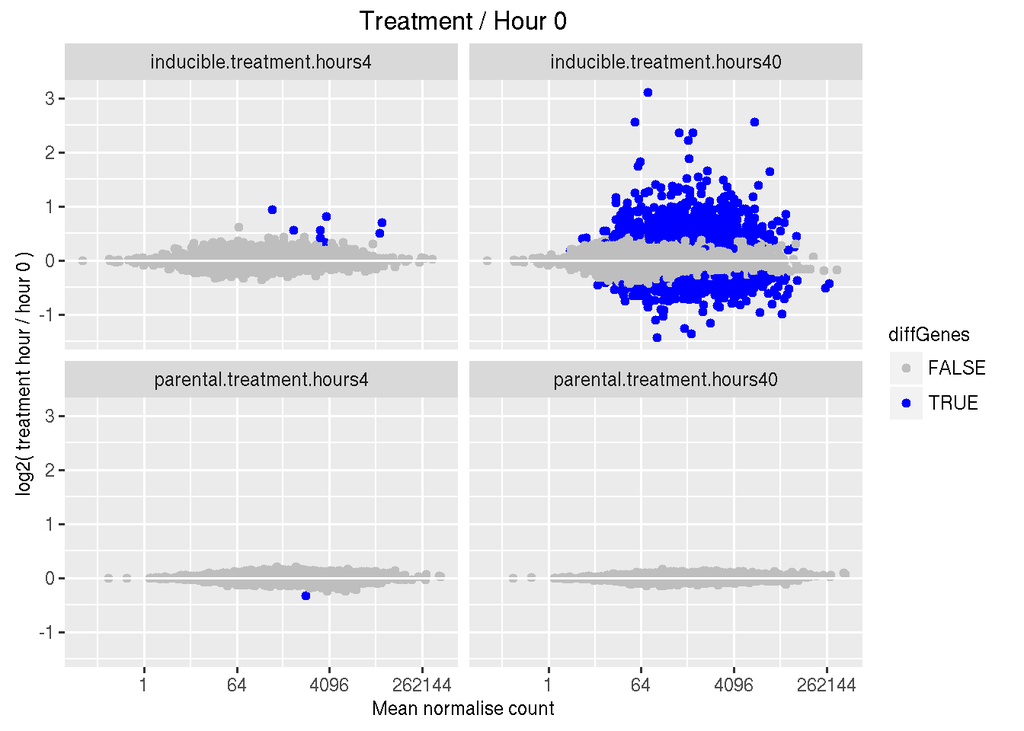

```r
plotdat <- data.frame( M = unlist( lapply( res, function( mat ) mat$log2FoldChange ) ),
                      A = unlist( lapply( res, function( mat ) mat$baseMean ) ),
                      diffGenes = unlist( lapply( res, function( mat ) mat$padj < 0.1 ) ),
                      contrast = unlist( lapply( names( res ), function( matN ) {
                                                    rep( matN, nrow( res[[ matN ]] ) )
                                                } ) ) )

gg <- ggplot( plotdat, aes( x=A, y=M, color=diffGenes ) ) +
    geom_point() +
        facet_wrap( ~contrast, nrow = 2 ) +
            scale_x_continuous( trans=log2_trans() ) +
                scale_color_manual(values=c( "grey", "blue1" ) ) +
                    labs( title = "Treatment / Hour 0",
                        y = "log2( treatment hour / hour 0 )",
                         x = "Mean normalise count" ) +
                        geom_abline( intercept = 0, slope = 0, color = "white" )
print( gg )
```